# Regression

Asher John

10/31/2021

## EX. 6.22

A. It is linear

B. IT is not linear and cannot be expressed in the form in 6.5.

C. It is linear.

D. It is not linear and cannot be expressd on the form in 6.5.

E. It is linear.

## EX. 6.31.

```r
library(readxl)
library(ggplot2)
library(dplyr)
library(broom)
library(ggpubr)
library(tidyverse)
library(coefplot)

mydata1 <- read_xlsx("Appendix.xlsx")

mydata <- mydata1[, c(3,2,4,9,11)]

mydata <- mydata %>% rename(Y = Infection_Risk, X_1 = Age, X_2 = Routine_Culturing_Ratio, X_3 = Average_Daily_Census, X_4 = Available_facilities_Services)

Region1 <- mydata[1:28, ]

Region2 <- mydata[29:60, ]

Region3 <- mydata[61:97, ]

Region4 <- mydata[98:113, ]
```

Region-1

```r
model1 <- lm(Y ~ X_1 + X_2 + X_3 + X_4, data = Region1)

anov1 <- aov(Y ~ X_1 + X_2 + X_3 + X_4, data = Region1)

summary(model1)
```

```
##
## Call:
## lm(formula = Y ~ X_1 + X_2 + X_3 + X_4, data = Region1)
##
## Residuals:
##      Min       1Q   Median       3Q      Max
## -2.67221 -0.62955  0.05195  0.72448  1.54486
##
## Coefficients:
##              Estimate Std. Error t value Pr(>|t|)
## (Intercept) -3.349576   2.709974  -1.236   0.2289
## X_1          0.116954   0.050215   2.329   0.0290 *
## X_2          0.058240   0.022609   2.576   0.0169 *
## X_3          0.001508   0.001651   0.913   0.3706
## X_4          0.006613   0.023041   0.287   0.7767
## ---
## Signif. codes:  0 '***' 0.001 '**' 0.01 '*' 0.05 '.' 0.1 ' ' 1
##
## Residual standard error: 1.011 on 23 degrees of freedom
## Multiple R-squared:  0.4613, Adjusted R-squared:  0.3676
## F-statistic: 4.924 on 4 and 23 DF,  p-value: 0.005128
```

Region-2

```r
model2 <- lm(Y ~ X_1 + X_2 + X_3 + X_4, data = Region2)

anov2 <- aov(Y ~ X_1 + X_2 + X_3 + X_4, data = Region2)

summary(model2)
```

```
##
## Call:
## lm(formula = Y ~ X_1 + X_2 + X_3 + X_4, data = Region2)
##
## Residuals:
##      Min       1Q   Median       3Q      Max
## -1.98794 -0.70073  0.09807  0.59809  2.07417
##
## Coefficients:
##             Estimate Std. Error t value Pr(>|t|)
## (Intercept) 2.291536   2.686553   0.853  0.40118
## X_1         0.004742   0.047213   0.100  0.92074
## X_2         0.058030   0.016192   3.584  0.00132 **
## X_3         0.001172   0.002094   0.560  0.58016
## X_4         0.015018   0.021510   0.698  0.49104
## ---
## Signif. codes:  0 '***' 0.001 '**' 0.01 '*' 0.05 '.' 0.1 ' ' 1
##
## Residual standard error: 1.101 on 27 degrees of freedom
## Multiple R-squared:  0.4115, Adjusted R-squared:  0.3243
## F-statistic: 4.719 on 4 and 27 DF,  p-value: 0.005111
```

Region-3

```r
model3 <- lm(Y ~ X_1 + X_2 + X_3 + X_4, data = Region3)

anov3 <- aov(Y ~ X_1 + X_2 + X_3 + X_4, data = Region3)

summary(model3)
```

```
##
## Call:
## lm(formula = Y ~ X_1 + X_2 + X_3 + X_4, data = Region3)
##
## Residuals:
##     Min      1Q  Median      3Q     Max
## -1.9122 -0.4960  0.1105  0.4411  2.3904
##
## Coefficients:
##              Estimate Std. Error t value Pr(>|t|)
## (Intercept) -0.143858   2.323190  -0.062   0.9510
## X_1          0.030848   0.039175   0.787   0.4368
## X_2          0.102281   0.021215   4.821 3.34e-05 ***
## X_3          0.004114   0.002160   1.905   0.0658 .
## X_4          0.008039   0.020362   0.395   0.6956
## ---
## Signif. codes:  0 '***' 0.001 '**' 0.01 '*' 0.05 '.' 0.1 ' ' 1
##
## Residual standard error: 0.9678 on 32 degrees of freedom
## Multiple R-squared:  0.6088, Adjusted R-squared:   0.56
## F-statistic: 12.45 on 4 and 32 DF,  p-value: 3.225e-06
```

Region-4

```r
model4 <- lm(Y ~ X_1 + X_2 + X_3 + X_4, data = Region4)

anov4 <- aov(Y ~ X_1 + X_2 + X_3 + X_4, data = Region4)

summary(model4)
```

```
##
## Call:
## lm(formula = Y ~ X_1 + X_2 + X_3 + X_4, data = Region4)
##
## Residuals:
##      Min       1Q   Median       3Q      Max
## -1.69113 -0.42384 -0.01758  0.77365  1.11734
##
## Coefficients:
##              Estimate Std. Error t value Pr(>|t|)
## (Intercept)  1.566549   4.382848   0.357    0.728
## X_1          0.035241   0.074383   0.474    0.645
## X_2          0.040328   0.058780   0.686    0.507
## X_3         -0.000664   0.003173  -0.209    0.838
## X_4          0.012792   0.025866   0.495    0.631
##
## Residual standard error: 0.9766 on 11 degrees of freedom
## Multiple R-squared:  0.0896, Adjusted R-squared:  -0.2415
## F-statistic: 0.2706 on 4 and 11 DF,  p-value: 0.8908
```

EX. 6.31.A. Estimated Regression Functions:

Region-1: Y = -3.349+0.116X_1+0.058X_2+0.002X_3+0.007X_4

Region-2: Y= 2.291+0.004X_1+0.058X_2+0.001X_3+0.015X_4

Region-3: Y= -0.144+0.030X_1+0.102X_2+0.004X_3+0.008X_4

Region-4: Y= 1.566+0.035X_1+0.040X_2-0.0006X_3+0.012X_4

6.31.B:

Estimated regression functions are not the same for any of the four regions. All the four regions have different intercepts and different estimated parameters. I asume that these differences are due to the normal variation in the data. One reason that can be attributed to the differences in estimated regression functions could be that sample size is very small for each region. Another reason for differences is the factors that have not been taken nto consideration in the model.

6.31.C

```r
summary(anov1)
```

```
##             Df Sum Sq Mean Sq F value  Pr(>F)
## X_1          1  7.363   7.363   7.207 0.01324 *
## X_2          1 10.311  10.311  10.091 0.00421 **
## X_3          1  2.367   2.367   2.317 0.14161
## X_4          1  0.084   0.084   0.082 0.77668
## Residuals   23 23.501   1.022
## ---
## Signif. codes:  0 '***' 0.001 '**' 0.01 '*' 0.05 '.' 0.1 ' ' 1
```

```r
summary(anov2)
```

```
##             Df Sum Sq Mean Sq F value  Pr(>F)
## X_1          1   2.24   2.240   1.849 0.18519
## X_2          1  15.83  15.826  13.059 0.00122 **
## X_3          1   4.22   4.220   3.482 0.07293 .
## X_4          1   0.59   0.591   0.487 0.49104
## Residuals   27  32.72   1.212
## ---
## Signif. codes:  0 '***' 0.001 '**' 0.01 '*' 0.05 '.' 0.1 ' ' 1
```

```r
summary(anov3)
```

```
##             Df Sum Sq Mean Sq F value   Pr(>F)
## X_1          1  1.102   1.102   1.176 0.286189
## X_2          1 28.827  28.827  30.774 4.04e-06 ***
## X_3          1 16.583  16.583  17.703 0.000195 ***
## X_4          1  0.146   0.146   0.156 0.695616
## Residuals   32 29.975   0.937
## ---
## Signif. codes:  0 '***' 0.001 '**' 0.01 '*' 0.05 '.' 0.1 ' ' 1
```

```r
summary(anov4)
```

```
##             Df Sum Sq Mean Sq F value Pr(>F)
## X_1          1  0.015  0.0147   0.015  0.904
## X_2          1  0.671  0.6712   0.704  0.419
## X_3          1  0.113  0.1134   0.119  0.737
## X_4          1  0.233  0.2333   0.245  0.631
## Residuals   11 10.492  0.9538
```

Region 1: R-squared: 0.4613, MSE: 1.022

Region 2: R-squared: 0.4115, MSE: 1.212

Region 3: R-squared: 0.6088, MSE: 0.937

Region 4: R-squared: 0.0896, MSE: 0.9538

All the above values are different this is also due to the smaller size of the samples from the different regions. Another reason for differences is the factors that have not been taken nto consideration in the model.

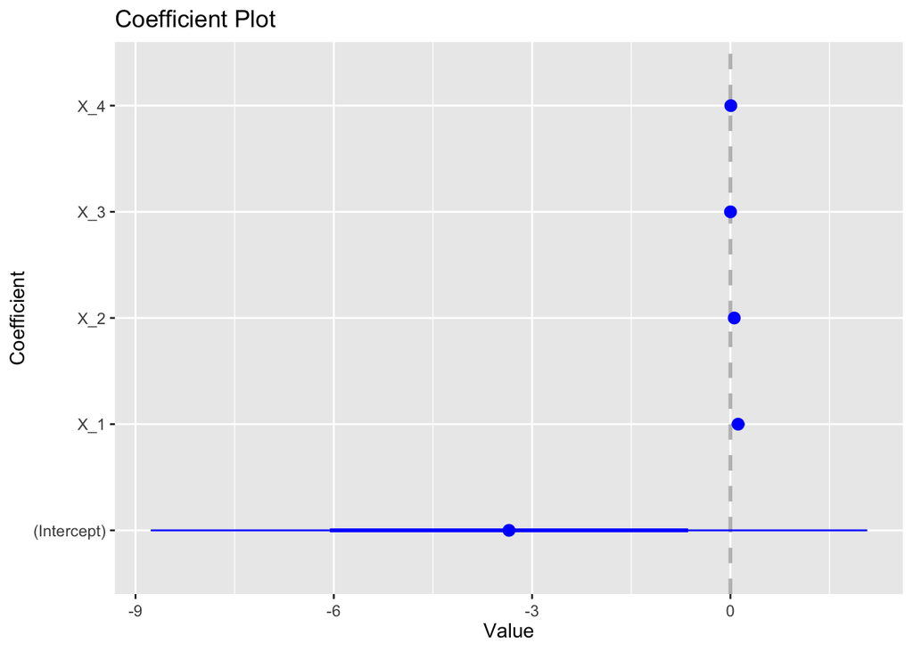

```r
coefplot(model1)
```

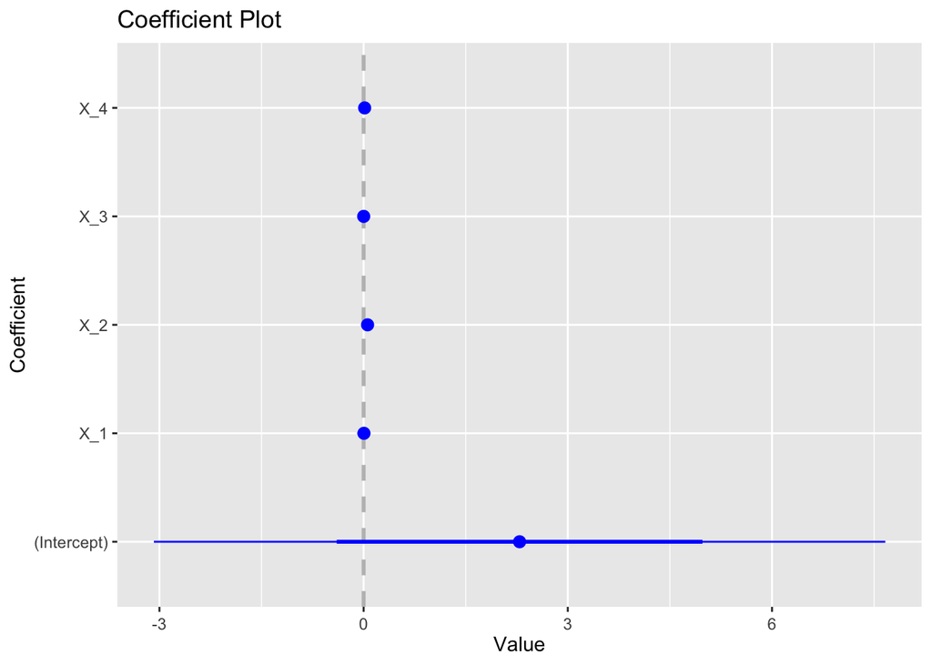

```r
coefplot(model2)
```

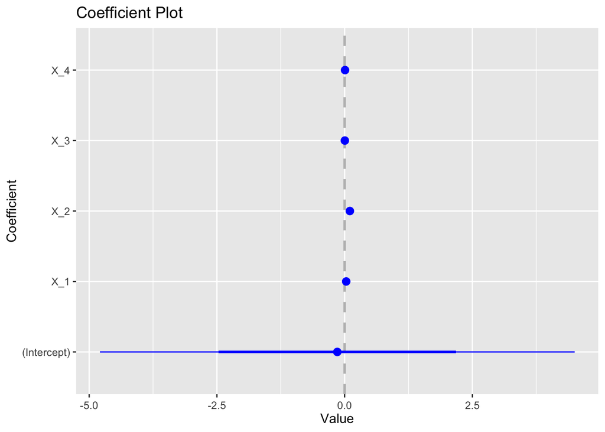

```r
coefplot(model3)
```

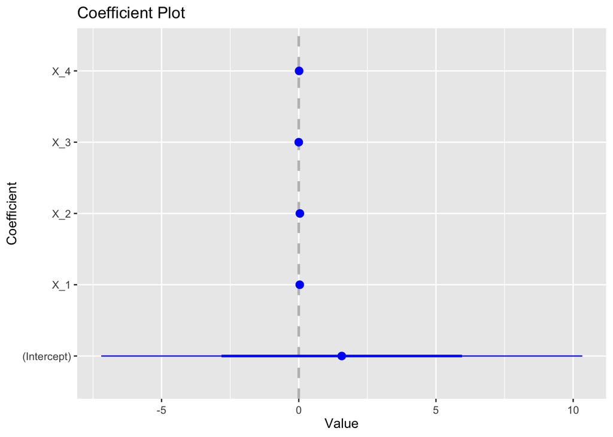

```r
coefplot(model4)
```

# EX. 7.4

```r
data6.9 <- read_excel("Data_6.9.xlsx")
summary(data6.9)
```

```
##        Y             X_1              X_2             X_3
##  Min.   :3998   Min.   :211944   Min.   :4.610   Min.   :0.0000
##  1st Qu.:4193   1st Qu.:268759   1st Qu.:6.805   1st Qu.:0.0000
##  Median :4316   Median :291271   Median :7.325   Median :0.0000
##  Mean   :4363   Mean   :302693   Mean   :7.371   Mean   :0.1154
##  3rd Qu.:4472   3rd Qu.:321906   3rd Qu.:7.938   3rd Qu.:0.0000
##  Max.   :5045   Max.   :472476   Max.   :9.650   Max.   :1.0000
```

```r
fit <- lm(Y ~ X_1 + X_2 + X_3, data = data6.9)

round(summary(fit)$coef, 4)
```

```
##              Estimate Std. Error t value Pr(>|t|)
## (Intercept) 4149.8872   195.5654 21.2199   0.0000
## X_1            0.0008     0.0004  2.1590   0.0359
## X_2          -13.1660    23.0917 -0.5702   0.5712
## X_3          623.5545    62.6409  9.9544   0.0000
```

```r
anova(fit)
```

```
## Analysis of Variance Table
##
## Response: Y
##           Df  Sum Sq Mean Sq F value    Pr(>F)
## X_1        1  136366  136366  6.6417   0.01309 *
## X_2        1    5726    5726  0.2789   0.59987
## X_3        1 2034514 2034514 99.0905 2.941e-13 ***
## Residuals 48  985530   20532
## ---
## Signif. codes:  0 '***' 0.001 '**' 0.01 '*' 0.05 '.' 0.1 ' ' 1
```

```r
fit.aov <- anova(fit)
tab <- as.table(cbind(
  'SS' = c("SSR(x1, x2, x3)" = sum(fit.aov[1:3, 2]),
         "SSR(x1)"           = fit.aov[1, 2],
         "SSR(x3|x1)"        = fit.aov[3, 2],
         "SSR(x2|x1, x3)"    = fit.aov[2, 2],
         "SSE"               = fit.aov[4, 2],
         "Total"             = sum(fit.aov[, 2])),

  'Df' = c(                    sum(fit.aov[1:3, 1]),
                               fit.aov[1, 1],
                               fit.aov[3, 1],
                               fit.aov[2, 1],
                               fit.aov[4, 1],
                               sum(fit.aov$Df)),

  'MS' = c(                    sum(fit.aov[1:3, 2]) / sum(fit.aov[1:3, 1]),
                               fit.aov[1, 3],
                               fit.aov[3, 3],
                               fit.aov[2, 3],
                               fit.aov[4, 3],
                               NA)
))

round(tab, 2)
```

```
##                         SS         Df         MS
## SSR(x1, x2, x3) 2176606.18       3.00  725535.39
## SSR(x1)          136366.24       1.00  136366.24
## SSR(x3|x1)      2034514.01       1.00 2034514.01
## SSR(x2|x1, x3)     5725.92       1.00    5725.92
## SSE              985529.75      48.00   20531.87
## Total           3162135.92      51.00
```

7.4-B.

The answer is based on 7.2 in the textbook.

7.4-C.

Yes, SSR(X1) +SSR(X2 given X1,) is equal SSR(X2) +SSR(X1 given X2) here. This will always be the case (refernce 7.8 & 7.9, page: 260 in the textbook).

# EX. 7.17

```r
scale1 <- data.frame(scale(data6.9))

model_scale <- lm(Y ~ X_1 + X_2 + X_3, data = scale1)

summary(model_scale)
```

```
##
## Call:
## lm(formula = Y ~ X_1 + X_2 + X_3, data = scale1)
##
## Residuals:
##      Min       1Q   Median       3Q      Max
## -1.06044 -0.44468 -0.09044  0.31843  1.18774
##
## Coefficients:
##               Estimate Std. Error t value Pr(>|t|)
## (Intercept) -1.420e-15  7.980e-02   0.000   1.0000
## X_1          1.747e-01  8.092e-02   2.159   0.0359 *
## X_2         -4.639e-02  8.137e-02  -0.570   0.5712
## X_3          8.079e-01  8.116e-02   9.954 2.94e-13 ***
## ---
## Signif. codes:  0 '***' 0.001 '**' 0.01 '*' 0.05 '.' 0.1 ' ' 1
##
## Residual standard error: 0.5755 on 48 degrees of freedom
## Multiple R-squared:  0.6883, Adjusted R-squared:  0.6689
## F-statistic: 35.34 on 3 and 48 DF,  p-value: 3.316e-12
```

```r
anova_scale1 <- anova(lm(Y ~ X_1 + X_2 + X_3, data = scale1))

anova_scale1
```

```
## Analysis of Variance Table
##
## Response: Y
##           Df Sum Sq Mean Sq F value    Pr(>F)
## X_1        1  2.199   2.199  6.6417   0.01309 *
## X_2        1  0.092   0.092  0.2789   0.59987
## X_3        1 32.813  32.813 99.0905 2.941e-13 ***
## Residuals 48 15.895   0.331
## ---
## Signif. codes:  0 '***' 0.001 '**' 0.01 '*' 0.05 '.' 0.1 ' ' 1
```

```r
round(summary(model_scale)$coef, 3)
```

```
##             Estimate Std. Error t value Pr(>|t|)
## (Intercept)    0.000      0.080   0.000    1.000
## X_1            0.175      0.081   2.159    0.036
## X_2           -0.046      0.081  -0.570    0.571
## X_3            0.808      0.081   9.954    0.000
```

```r
cor(scale1)
```

```
##             Y        X_1        X_2        X_3
## Y   1.0000000 0.20766494 0.06002960 0.81057940
## X_1 0.2076649 1.00000000 0.08489639 0.04565698
## X_2 0.0600296 0.08489639 1.00000000 0.11337076
## X_3 0.8105794 0.04565698 0.11337076 1.00000000
```

7.17.A.

Y= 0.175X_1 - 0.046X_2 + 0.808X_3

7.17.B.

This table shows relationship between all predictor variables and the respnse varoable and it is meaniningful as it shows that X-3 has the strongest correlation with the response variable.

7.17.C.

For transforming back to the original equation we use the following, these values were calculated on excel:

```
      b1 = (sY/s_1)b*_1 = (249/55274.64)*0.175 = 0.0008

      b2 = (sY/s_2)b*_2 = (249/0.88)*-0.046 = -13.02

      b3 = (sY/s_3)b*_3 = (249/0.323)*0.808 = 622.89
```

For b_0 the formula on p. 277 from the textbook (last line is used) cannot be typed here!

```
      b_0 = 4363-.0008*302693 + 13.02*7.371 - 622.89*0.1154 = 4145
```

# EX. 7.38

Preparing the data

```r
library(readxl)
mydata2 <- read_excel("Book2.xlsx")
mydata2
```

```
## # A tibble: 113 × 11
##    `Lengh of stay`   Age `Infection Risk` `Routine Culturing… `Routine Chest Xr…
##              <dbl> <dbl>            <dbl>               <dbl>              <dbl>
##  1            7.13  55.7              4.1                 9                 39.6
##  2            8.82  58.2              1.6                 3.8               51.7
##  3            8.34  56.9              2.7                 8.1               74
##  4            8.95  53.7              5.6                18.9              123.
##  5           11.2   56.5              5.7                34.5               88.9
##  6            9.76  50.9              5.1                21.9               97
##  7            9.68  57.8              4.6                16.7               79
##  8           11.2   45.7              5.4                60.5               85.8
##  9            8.67  48.2              4.3                24.4               90.8
## 10            8.84  56.3              6.3                29.6               82.6
## # … with 103 more rows, and 6 more variables: Number of Beds <dbl>,
## #   Medical School Affiliation <dbl>, Region <dbl>, Average Daily Census <dbl>,
## #   Number of Nurses <dbl>, Available facilities and Services <dbl>
```

```r
df.2 <- mydata2[, c(1,2,3,4,9,10,11)]

df.2
```

```
## # A tibble: 113 × 7
##    `Lengh of stay`   Age `Infection Risk` `Routine Culturing… `Average Daily Ce…
##              <dbl> <dbl>            <dbl>               <dbl>              <dbl>
##  1            7.13  55.7              4.1                 9                  207
##  2            8.82  58.2              1.6                 3.8                 51
##  3            8.34  56.9              2.7                 8.1                 82
##  4            8.95  53.7              5.6                18.9                 53
##  5           11.2   56.5              5.7                34.5                134
##  6            9.76  50.9              5.1                21.9                147
##  7            9.68  57.8              4.6                16.7                151
##  8           11.2   45.7              5.4                60.5                399
##  9            8.67  48.2              4.3                24.4                130
## 10            8.84  56.3              6.3                29.6                 59
## # … with 103 more rows, and 2 more variables: Number of Nurses <dbl>,
## #   Available facilities and Services <dbl>
```

```r
df.2 <- df.2 %>% rename(Y = "Lengh of stay", X_1 = "Age",
                        X_2 = "Infection Risk",
                        X_3 = "Routine Culturing Ratio", X_4 = "Average Daily Census", X_5 = "Number of Nurses", X_6 = "Available facilities and Services")

df.2
```

```
## # A tibble: 113 × 7
##        Y   X_1   X_2   X_3   X_4   X_5   X_6
##    <dbl> <dbl> <dbl> <dbl> <dbl> <dbl> <dbl>
##  1  7.13  55.7   4.1   9     207   241    60
##  2  8.82  58.2   1.6   3.8    51    52    40
##  3  8.34  56.9   2.7   8.1    82    54    20
##  4  8.95  53.7   5.6  18.9    53   148    40
##  5 11.2   56.5   5.7  34.5   134   151    40
##  6  9.76  50.9   5.1  21.9   147   106    40
##  7  9.68  57.8   4.6  16.7   151   129    40
##  8 11.2   45.7   5.4  60.5   399   360    60
##  9  8.67  48.2   4.3  24.4   130   118    40
## 10  8.84  56.3   6.3  29.6    59    66    40
## # … with 103 more rows
```

```r
model7.38 <- lm(Y ~ X_1 + X_2 + X_3 + X_4, X_5, X_6, data = df.2)

anova_1 <- anova(lm(Y ~ X_1 + X_2 + X_3 + X_4, X_5, X_6, data = df.2))
anova_1
```

```
## Analysis of Variance Table
##
## Response: Y
##           Df Sum Sq Mean Sq F value    Pr(>F)
## X_1        1  909.5   909.5  12.113  0.001142 **
## X_2        1 2133.1  2133.1  28.412 3.217e-06 ***
## X_3        1 1406.5  1406.5  18.733 8.535e-05 ***
## X_4        1 3236.1  3236.1  43.103 4.972e-08 ***
## Residuals 44 3303.5    75.1
## ---
## Signif. codes:  0 '***' 0.001 '**' 0.01 '*' 0.05 '.' 0.1 ' ' 1
```

7.38 A

```r
anova_2 <- anova(lm(Y ~ X_1 + X_2 + X_3, data = df.2))

anova_2
```

```
## Analysis of Variance Table
##
## Response: Y
##            Df  Sum Sq Mean Sq F value  Pr(>F)
## X_1         1  14.604  14.604  5.7885 0.01781 *
## X_2         1 116.356 116.356 46.1188 6.1e-10 ***
## X_3         1   3.248   3.248  1.2874 0.25902
## Residuals 109 275.002   2.523
## ---
## Signif. codes:  0 '***' 0.001 '**' 0.01 '*' 0.05 '.' 0.1 ' ' 1
```

```r
anova_2[3,2]/anova(lm(Y ~ X_1 + X_2, data = df.2)) [3,2]
```

```
## [1] 0.01167293
```

```r
anova_3 <- anova(lm(Y ~ X_1 + X_2 + X_4, data = df.2))
anova_3
```

```
## Analysis of Variance Table
##
## Response: Y
##            Df  Sum Sq Mean Sq F value    Pr(>F)
## X_1         1  14.604  14.604   6.623   0.01141 *
## X_2         1 116.356 116.356  52.768 5.928e-11 ***
## X_4         1  37.899  37.899  17.187 6.722e-05 ***
## Residuals 109 240.352   2.205
## ---
## Signif. codes:  0 '***' 0.001 '**' 0.01 '*' 0.05 '.' 0.1 ' ' 1
```

```r
anova_3[3,2]/anova(lm(Y ~ X_1 + X_2, data = df.2)) [3,2]
```

```
## [1] 0.1362033
```

```r
anova_4 <- anova(lm(Y ~ X_1 + X_2 + X_5, data = df.2))
anova_4
```

```
## Analysis of Variance Table
##
## Response: Y
##            Df  Sum Sq Mean Sq F value    Pr(>F)
## X_1         1  14.604  14.604   5.943   0.01639 *
## X_2         1 116.356 116.356  47.350 3.931e-10 ***
## X_5         1  10.397  10.397   4.231   0.04208 *
## Residuals 109 267.853   2.457
## ---
## Signif. codes:  0 '***' 0.001 '**' 0.01 '*' 0.05 '.' 0.1 ' ' 1
```

```r
anova_4[3,2]/anova(lm(Y ~ X_1 + X_2, data = df.2)) [3,2]
```

```
## [1] 0.03736635
```

```r
anova_5 <- anova(lm(Y ~ X_1 + X_2 + X_6, data = df.2))
anova_5
```

```
## Analysis of Variance Table
##
## Response: Y
##            Df  Sum Sq Mean Sq F value    Pr(>F)
## X_1         1  14.604  14.604  5.9370   0.01645 *
## X_2         1 116.356 116.356 47.3017 3.998e-10 ***
## X_6         1  10.125  10.125  4.1162   0.04491 *
## Residuals 109 268.125   2.460
## ---
## Signif. codes:  0 '***' 0.001 '**' 0.01 '*' 0.05 '.' 0.1 ' ' 1
```

```r
anova_5[3,2]/anova(lm(Y ~ X_1 + X_2, data = df.2)) [3,2]
```

```
## [1] 0.03638879
```

7.38 A

coefficients of partial determination are as following:

X_3|X_1,X_2 = 0.01167293, extra sum of squares = 3.248

X_4|X_1,X_2 = 0.1362033, extra sum of squares = 37.899

X_5|X_1,X_2 = 0.03736635, extra sum of squares = 10.397

X_6|X_1,X_2 = 0.03638879, extra sum of squares = 10.125

7.38-B.

As we can see from the data above X_4 is the best predictor as it has the most part in explianing the variation in Y given the X_1 and X-2 are already there. It also has the larger extra sum of squares (37.899) as compared to others.

7.38-C.